# MA40198: Applied Statistical Inference

Lab 2: Quasi-Newton optimisation algorithms

2024-10-03

# BFGS quasi-Newton algorithm

Consider minimisation of an objective function $\phi(\boldsymbol{\theta})$ where $\boldsymbol{\theta}\in R^p$. For a given:

- initial point $\boldsymbol{\boldsymbol{\theta}}_0$
- initial positive definite matrix $\boldsymbol{B}_0$

the BFGS algorithm iterations are given by:

$$\boldsymbol{\boldsymbol{\theta}}_{k+1}=\boldsymbol{\boldsymbol{\theta}}_{k}+\alpha_k\,\boldsymbol{\Delta}_k$$

where $\alpha_k>0$ is the step-length, $\boldsymbol{\Delta}_k$ is given by:

$$\boldsymbol{\Delta}_k=-\boldsymbol{B}_k\,\nabla_{\!\boldsymbol{\theta}}
\phi(\boldsymbol{\theta}_k)$$

and $\{\boldsymbol{B}_{k}\}$ are symmetric positive definite matrices given by the iteration:

$$\boldsymbol{B}_{k+1}=
\left(\boldsymbol{I}-
\frac{
\boldsymbol{\Delta}_k\boldsymbol{\eta}_k^T}{\boldsymbol{\eta}_k^T\boldsymbol{\Delta}_k}\right)\boldsymbol{B}_k\left(\boldsymbol{I}-\frac{\boldsymbol{\eta}_k\boldsymbol{\Delta}_k^T}{\boldsymbol{\eta}_k^T\boldsymbol{\Delta}_k}\right)+\alpha_k\,\frac{\boldsymbol{\Delta}_k\boldsymbol{\Delta}_k^T}{\boldsymbol{\eta}_k^T\boldsymbol{\Delta}_k}$$

where

$$\boldsymbol{\eta}_k=\nabla_{\!\boldsymbol{\theta}}
\phi(\boldsymbol{\boldsymbol{\theta}}_{k+1})-\nabla_{\!\boldsymbol{\theta}}
\phi(\boldsymbol{\boldsymbol{\theta}}_{k})$$

The main idea is that the matrices $\{\boldsymbol{B}_k\}$ play the role of the inverse of the Hessian matrix at each iteration in Newton’s algorithm. The advantage of this new algorithm is that we do not need to compute the Hessian nor to solve a linear system as Newton’s algorithm requires.

Below you can find generic code to run the BFGS algorithm to answer the following questions.

```r
BFGS<-function(par , # vector of starting values
               fn  , # objective function
               gr  , # function to compute the gradient
               hess, # function to compute the Hessian
                      # Only to compute distance to approximate Hessian
               B  , # initial inverse Hessian approximation
               control=list(maxit    = 1000,
                            abstol   = 1e-5,
                            maxit_bt = 100), # control parameters
               ...){ #  can pass extra arguments to 'fn' and `gr`  via ...  "the ellipsis"
   k    <- 1

  # convergence indicator (0 = converged successfully, 1 = max iteration reached)
  conv <- 0

  p            <- length(par) # dimension of space

  par_current  <- par

  fn_current   <- fn(par_current,...) # evaluate objective function

  grad_current <- gr(par_current,...) # evaluate gradient

  hess_current <- hess(par_current,...) # evaluate exact Hessian (Only to compute distance to approximate Hessian)

  # note additional arguments are passed on using the ellipsis ...

  # other initialisations

  par_seq        <- matrix(NA,nrow=control$maxit,ncol=p) #sequence of iterations
  par_seq[k,]    <- par_current
  k_backtracking   <- rep(NA,control$maxit)                # sequence of backtracking iterations


  while(norm(grad_current,type="2")>control$abstol){ # stopping criterion

  Delta <- -B %*% grad_current # computes descent direction

   alpha         <- 1   # initial step length

   par_proposed  <- par_current + alpha*Delta

  fn_proposed   <- fn(par_proposed,...) # evaluate objective fun at proposed point




  # backtracking


 k_bt <- 0 # backtracking iteration counter

  # maxit_bt is the maximum number of backtracking iterations

  while ((fn_proposed >= fn_current)&(k_bt < control$maxit_bt)){

    k_bt           <- k_bt+1 # counter for the number of backtracking iterations

    alpha          <- alpha/2

   par_proposed  <- par_current + alpha*Delta

   fn_proposed   <- fn(par_proposed,...)

  }# End of backtracking


  k_backtracking[k]<-k_bt

  # updating

  grad_old     <- grad_current

  par_current  <- par_proposed

  fn_current   <- fn_proposed

  grad_current <- gr(par_current,...)

  hess_current <- hess(par_current,...)

  eta          <- grad_current - grad_old

  rho <- 1/as.numeric(crossprod(eta,Delta))
  # uses as.numeric to convert from a matrix of dimension 1 x 1 to a scale

  # approximation to inverse Hessian
  B   <- (diag(p)-rho*tcrossprod(Delta,eta))%*%B%*%(diag(p)-rho*tcrossprod(eta,Delta)) +  alpha*rho* tcrossprod(Delta)

  k   <- k+1

  # storage of iterations info

  par_seq[k,]      <- par_current

  if (k == control$maxit){

    conv <-1

    break  # breaks while loop if maximum number of iterations is reached

  }

}

return(list(par           = par_current,
            value         = fn_current,
            convergence   = conv,
            iterations    = k,
            par_seq       = par_seq[1:k,],
            inv_hess      = B,
            backtracks    = k_backtracking[1:k]))
}
```

# Questions

## Question 1

**AIDS epidemic in Belgium.**

The following data are reported AIDS cases in Belgium, in the early stages of am epidemic.

| Year | 1981 | 1982 | 1983 | 1984 | 1985 | 1986 | 1987 | 1988 | 1989 | 1990 | 1991 | 1992 | 1993 |
| --- | --- | --- | --- | --- | --- | --- | --- | --- | --- | --- | --- | --- | --- |
| Cases | 12 | 14 | 33 | 50 | 67 | 74 | 123 | 141 | 165 | 204 | 253 | 246 | 240 |

One important question, early in such epidemics, is whether control measures are beginning to have an impact or whether the disease is continuing to spread essentially unchecked. A simple model for unchecked growth leads to an *exponential increase* model. The model says that the number of cases $y_i$ is an observation of an independent Poisson random variable, with expected value $\mu_i = \exp(\theta^*_1+\theta^*_2\,t_i)$ where $t_i$ is the number of years since 1980.

## Solution to Question 1

```r
tdat<-1:13
ydat<-c(12,14,33,50,67,74,123,141,165,204,253,246,240)
Data <- data.frame(t=tdat, y=ydat)
expr <- expression(-y*(theta1+theta2*t)+(exp(theta1+theta2*t)+lgamma(y+1)) # this is only the negative log-density
)
aux <- deriv(expr,c("theta1","theta2"),function.arg=c("theta1","theta2","t","y"),hessian=TRUE)

fn <- function(theta,t,y) {
  res <- aux(theta[1],theta[2],t,y)
  sum(as.numeric(res))
}
gr <- function(theta,t,y) {
  res <- aux(theta[1],theta[2],t,y)
  apply(attr(res,"gradient"),2,sum)
}
hess <- function(theta,t,y) {
  res <- aux(theta[1],theta[2],t,y)
  apply(attr(res,"hessian"),c(2,3),sum)
}

res<-BFGS(par=c(log(5), 0.5),
     fn=fn,
     gr=gr,
     hess=hess,
     B=diag(2),
     t=tdat,
     y=ydat)

res
```

```
## $par
##           [,1]
## [1,] 3.1405895
## [2,] 0.2021212
##
## $value
## [1] 81.18491
##
## $convergence
## [1] 0
##
## $iterations
## [1] 13
##
## $par_seq
##           [,1]       [,2]
##  [1,] 1.609438  0.5000000
##  [2,] 1.583431  0.1895487
##  [3,] 5.082036 -0.1125745
##  [4,] 2.988398  0.1062479
##  [5,] 2.515870  0.2094113
##  [6,] 2.419079  0.3043292
##  [7,] 2.970803  0.2078109
##  [8,] 3.111654  0.2024655
##  [9,] 3.145013  0.2018048
## [10,] 3.140883  0.2020875
## [11,] 3.140610  0.2021185
## [12,] 3.140589  0.2021212
## [13,] 3.140590  0.2021212
##
## $inv_hess
##               [,1]          [,2]
## [1,]  0.0061180367 -0.0005761501
## [2,] -0.0005761501  0.0000603374
##
## $backtracks
##  [1] 18  6  0  0  0  0  0  0  0  0  0  0 NA
```

```r
theta1_grid <- seq(0,4,length=100)
theta2_grid <- seq(0.1,0.5,length=100)
```

```r
for (i in 1:100){
  for (j in 1:100){
    M[i,j]<-fn(theta = c(theta1=theta1_grid[i],
                         theta2=theta2_grid[j]),
               t     = t,
               y     = y)
  }
}
```

```
## Error in theta2 * t: non-numeric argument to binary operator
```

**KAI: THis throws an error , see below for the correct answer**

```r
M<-matrix(NA,100,100)
for (i in 1:100){
  for (j in 1:100){
    M[i,j]<-fn(theta = c(theta1=theta1_grid[i],
                         theta2=theta2_grid[j]),
               t     = tdat,
               y     = ydat)
  }
}
```

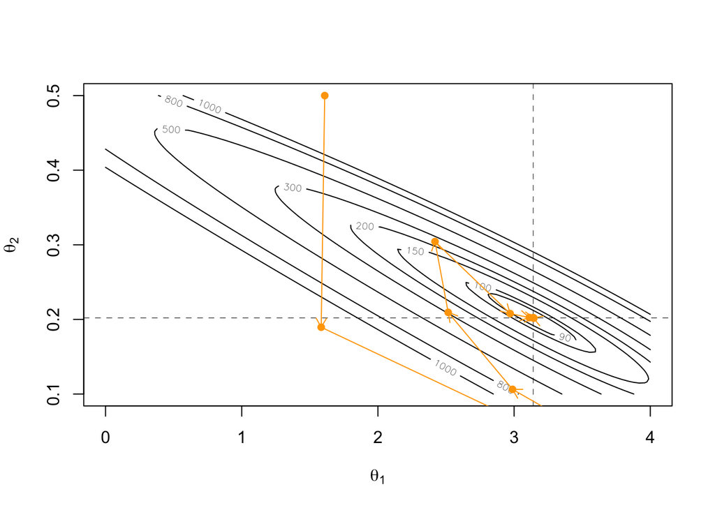

```r
contour(x = theta1_grid,
        y = theta2_grid,
        levels=c(90,100,150,200,300,500,800,1000),
        z = M,
        xlab=expression(theta[1]),
        ylab=expression(theta[2]))

abline(h=0.202,lty=2,lwd=0.5)
abline(v=3.14,lty=2,lwd=0.5)


## KAI I completed your code here
##
theta_seq = res$par_seq
it.stop <-res$iterations
###
points(x   = theta_seq [,1],
       y   = theta_seq [,2],
       col = "orange",
       pch = 16)

arrows(x0     = theta_seq [1:(it.stop -1),1],
       y0     = theta_seq [1:(it.stop -1),2],
       x1     = theta_seq [2:(it.stop ),1],
       y1     = theta_seq [2:(it.stop ),2],
       col    = "orange",
       length = 0.1)
```

```r
opt2<-BFGS(par=c(1, 0.56),
     fn=fn,
     gr=gr,
     hess=hess,
     B=diag(x=2,nrow=2,ncol=2),
     t=tdat,
     y=ydat)

opt2
```

```
## $par
##           [,1]
## [1,] 3.1405895
## [2,] 0.2021212
##
## $value
## [1] 81.18491
##
## $convergence
## [1] 0
##
## $iterations
## [1] 14
##
## $par_seq
##            [,1]        [,2]
##  [1,] 1.0000000  0.56000000
##  [2,] 0.9711225  0.20963072
##  [3,] 5.0849407 -0.14095388
##  [4,] 3.0767130  0.07068719
##  [5,] 2.3881187  0.21683571
##  [6,] 2.2996954  0.27789809
##  [7,] 2.8850496  0.22585261
##  [8,] 3.2034084  0.19656737
##  [9,] 3.1362157  0.20241604
## [10,] 3.1403278  0.20216859
## [11,] 3.1406853  0.20210939
## [12,] 3.1405880  0.20212132
## [13,] 3.1405896  0.20212120
## [14,] 3.1405895  0.20212120
##
## $inv_hess
##               [,1]          [,2]
## [1,]  0.0061340742 -5.780751e-04
## [2,] -0.0005780751  6.056873e-05
##
## $backtracks
##  [1] 19  7  0  0  1  0  0  0  0  0  0  0  0 NA
```

```r
## Similar results for different value of theta and B
```